# 2024 Client Feedback Survey Data

# Introduction

The following report presents data visualizations from the **2024 Client Feedback Survey**, which gathered feedback from clients receiving services across CoC projects. These visualizations summarize responses across all projects rather than by individual project. This approach was taken because some projects had very few responses which would not provide meaningful insights at the project level.

The report is structured into five sections, each focusing on a specific survey question. Responses are broken down by **age group, chronic status, gender, and race/ethnicity** to highlight trends and disparities among different populations. Our goal is to provide a clearer understanding of client experiences and identify areas for improvement in service delivery.

**Note on Race/Ethnicity Data:** Some survey respondents did not select a race/ethnicity category, resulting in responses categorized as *Data Not Collected*. Since this category does not provide meaningful insights into racial disparities, we have excluded these responses from the Race/Ethnicity visualizations. However, their responses are still included in the other demographic breakdowns.

## Maintaining Housing

**“How confident are you that you will be able to maintain your own housing independently after your rental assistance through the program ends?”**

### By Age Group

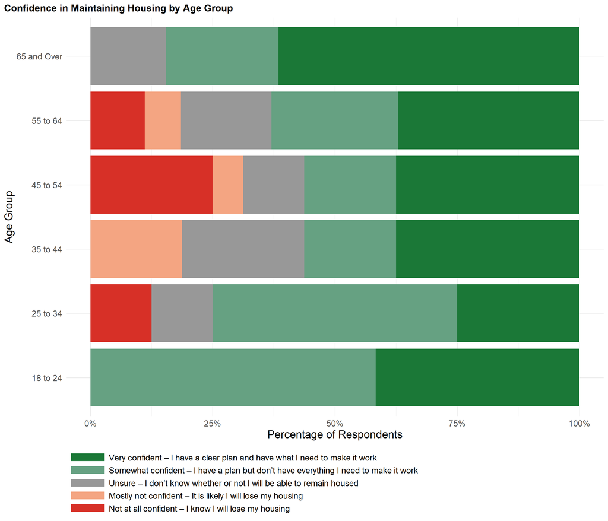

### By Chronic Status

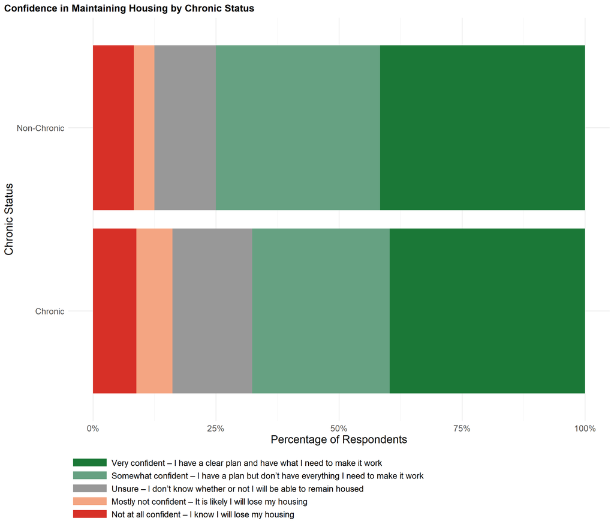

### By Gender

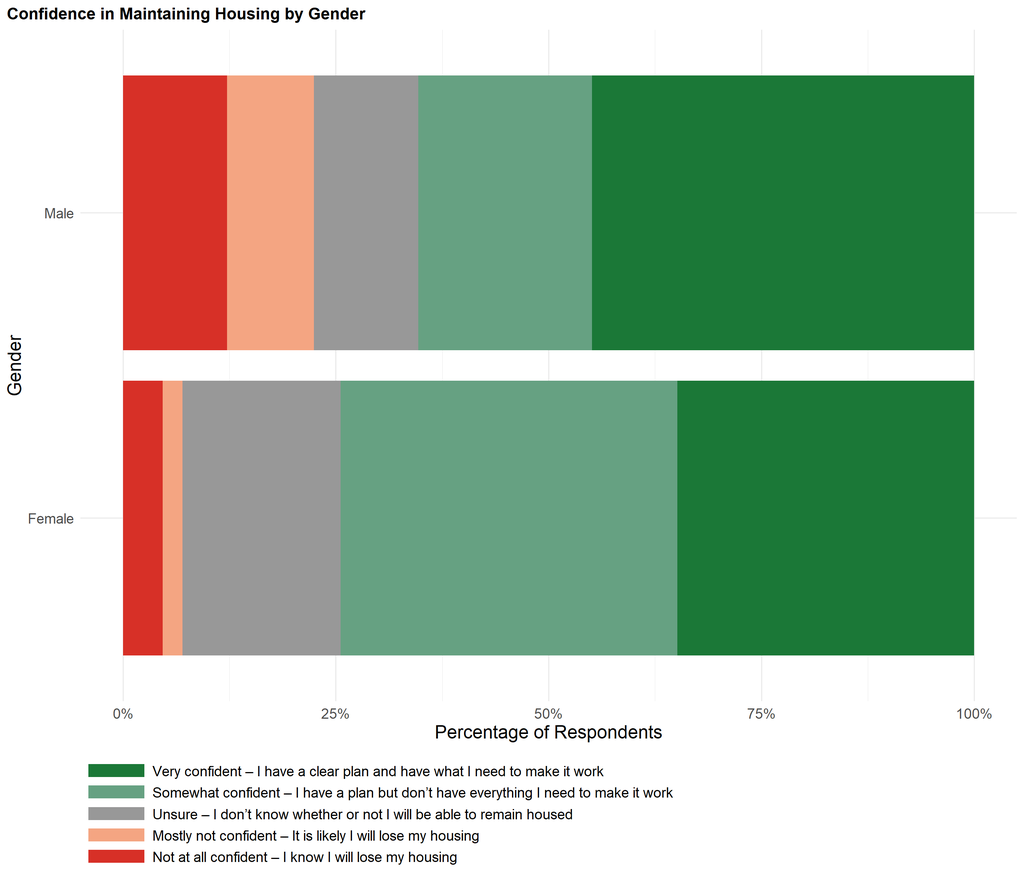

### By Race/Ethnicity

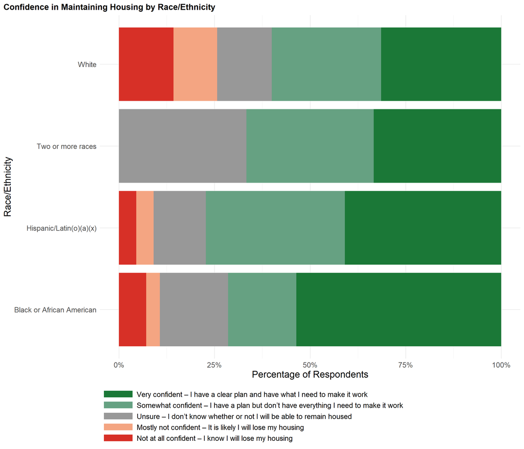

## Housing Supports

**“How available is housing assistance through your housing program?”**

### By Age Group

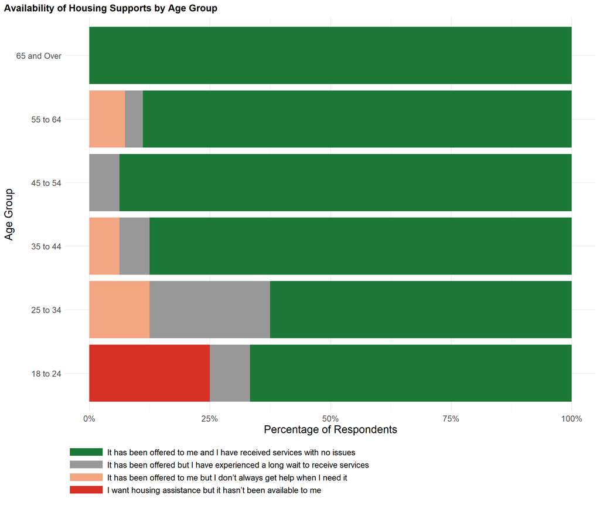

### By Chronic Status

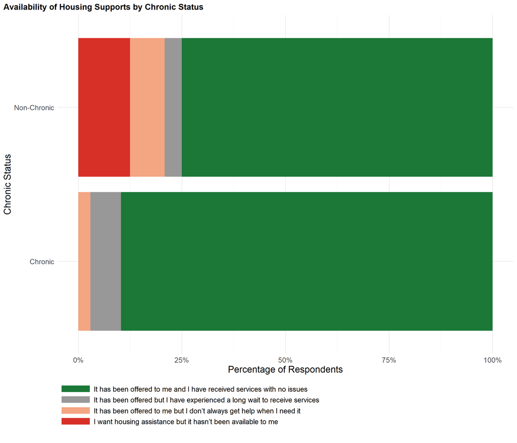

### By Gender

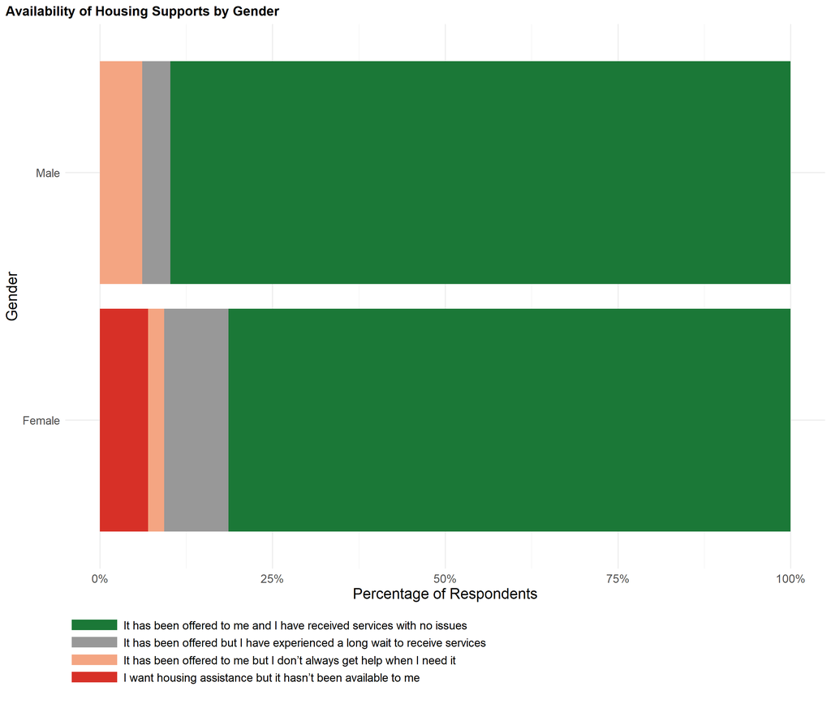

### By Race/Ethnicity

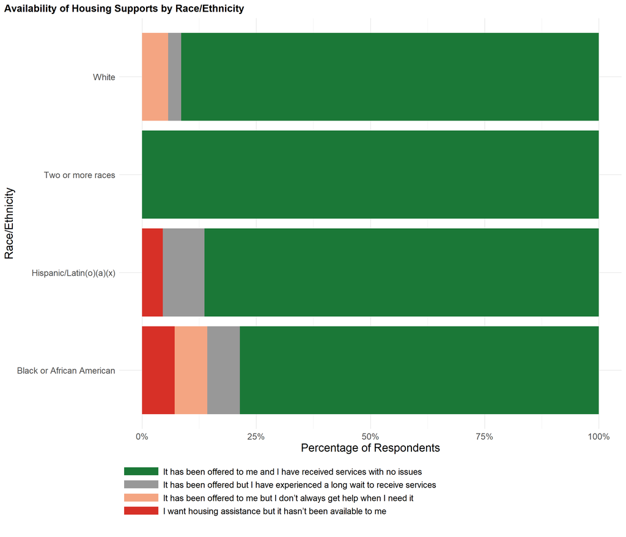

## Respected by Case Manager

**“Do you feel like your identity is respected by your case manager?”**

### By Age Group

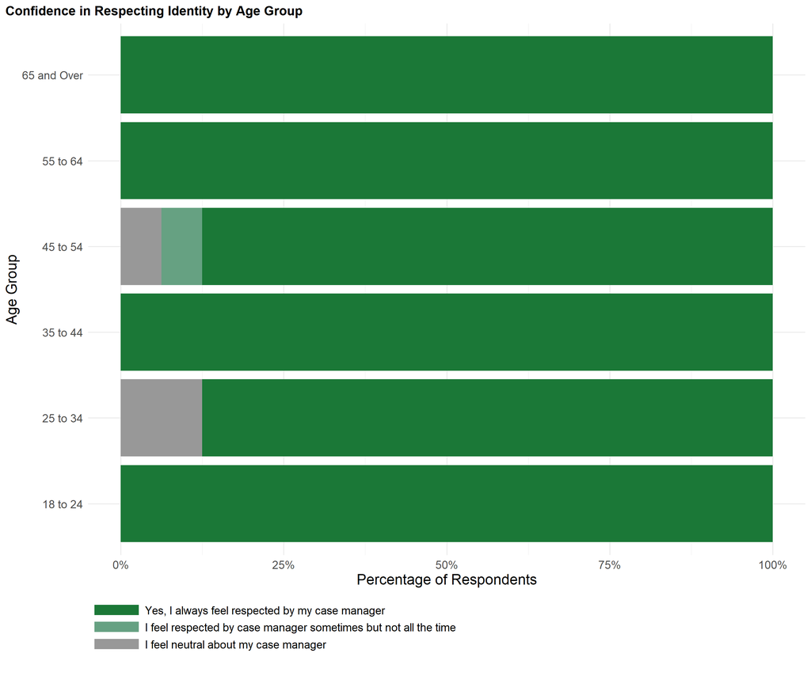

### By Chronic Status

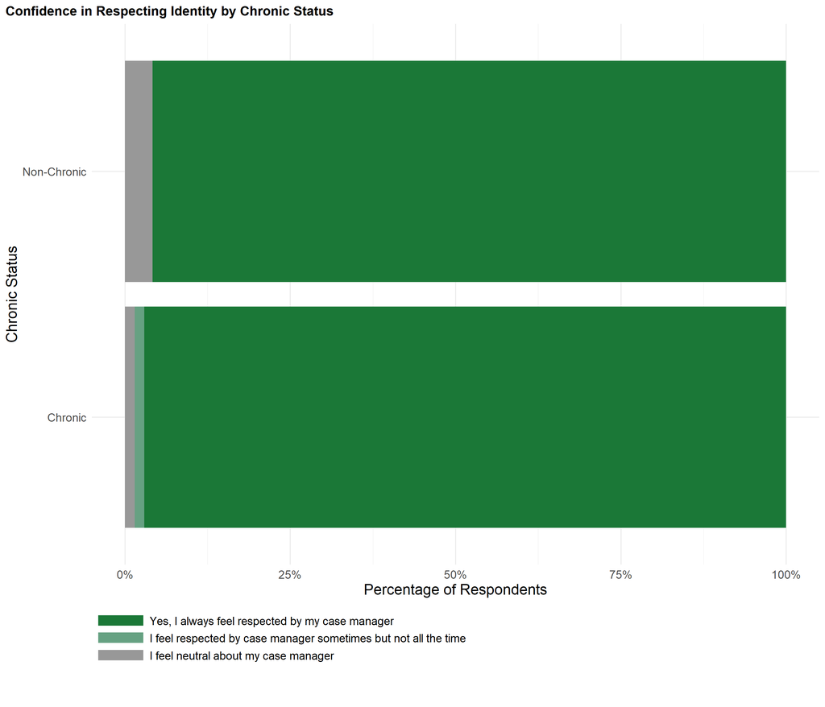

### By Gender

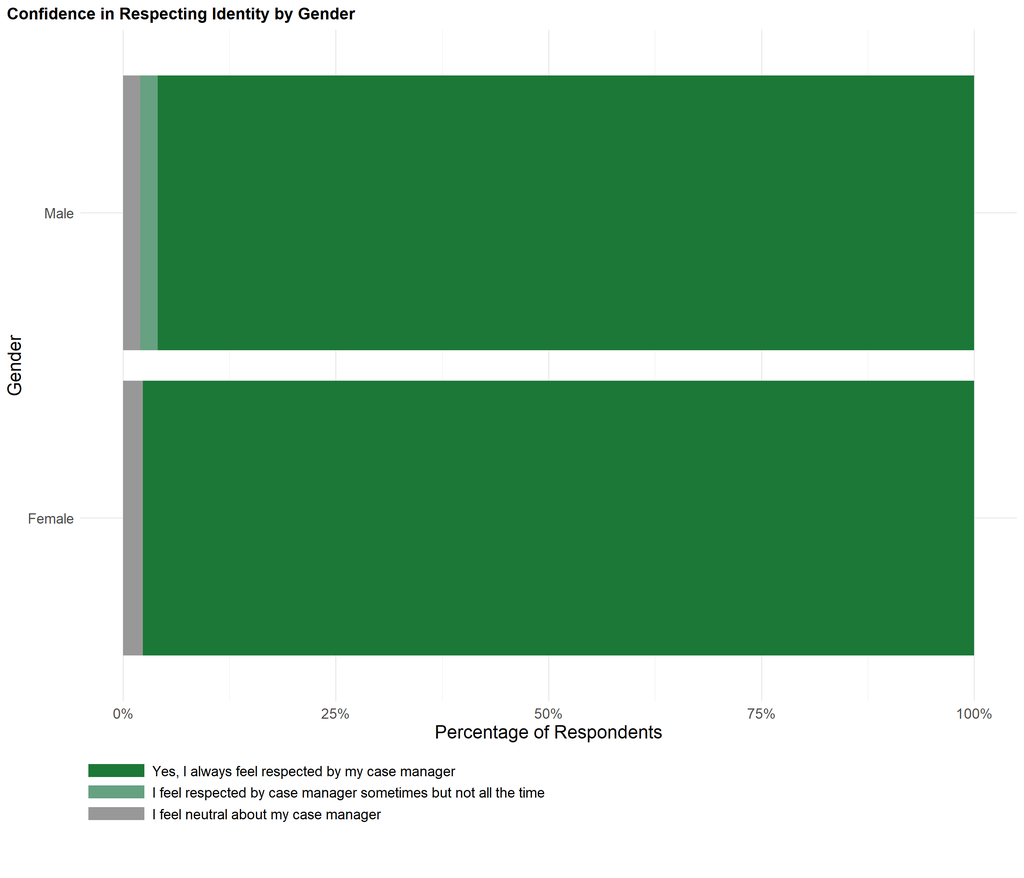

### By Race/Ethnicity

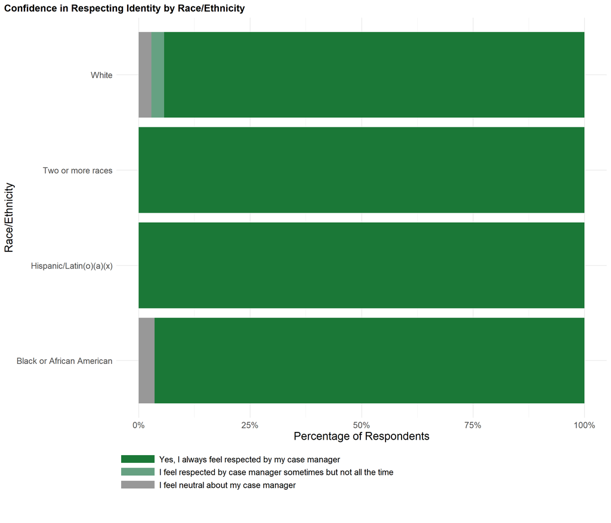

## Individualized Service Plan

**“Was your service plan individualized for you after assessing your strengths and housing needs?”**

### By Age Group

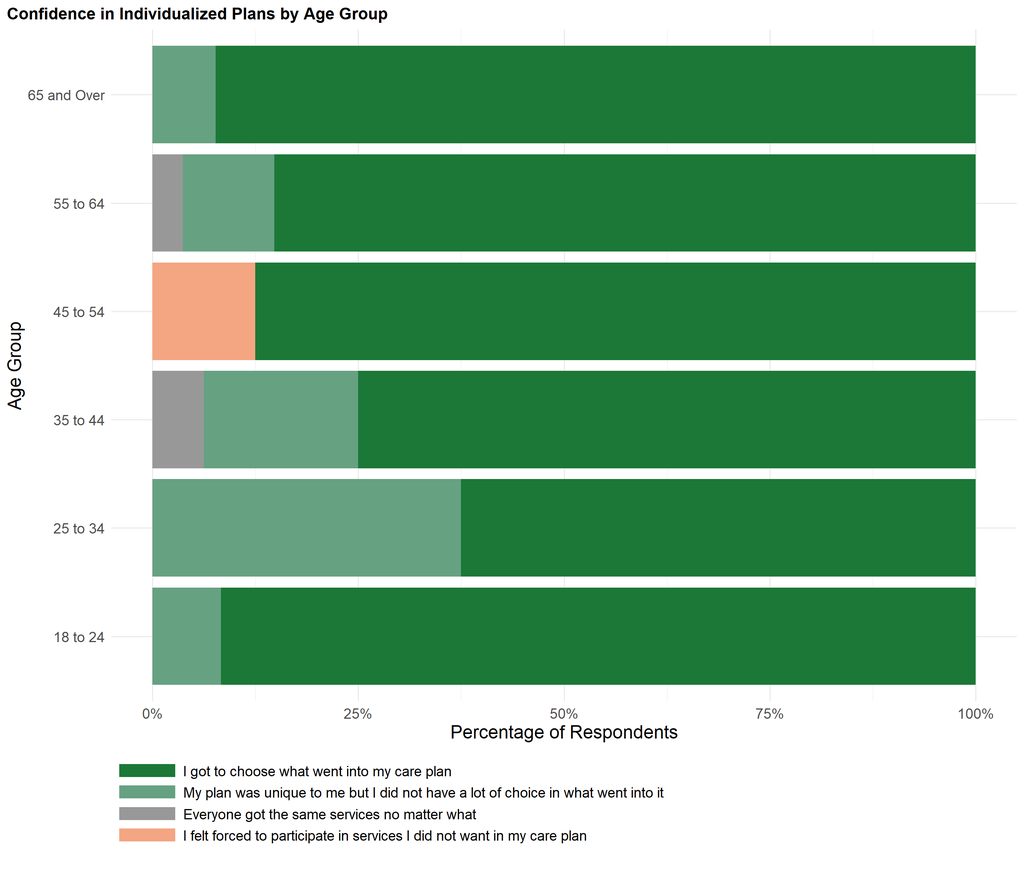

### By Chronic Status

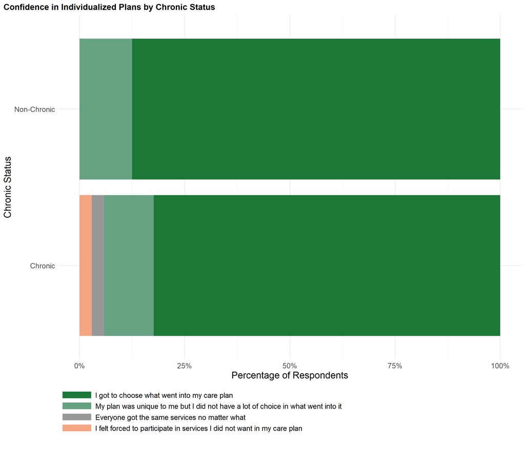

### By Gender

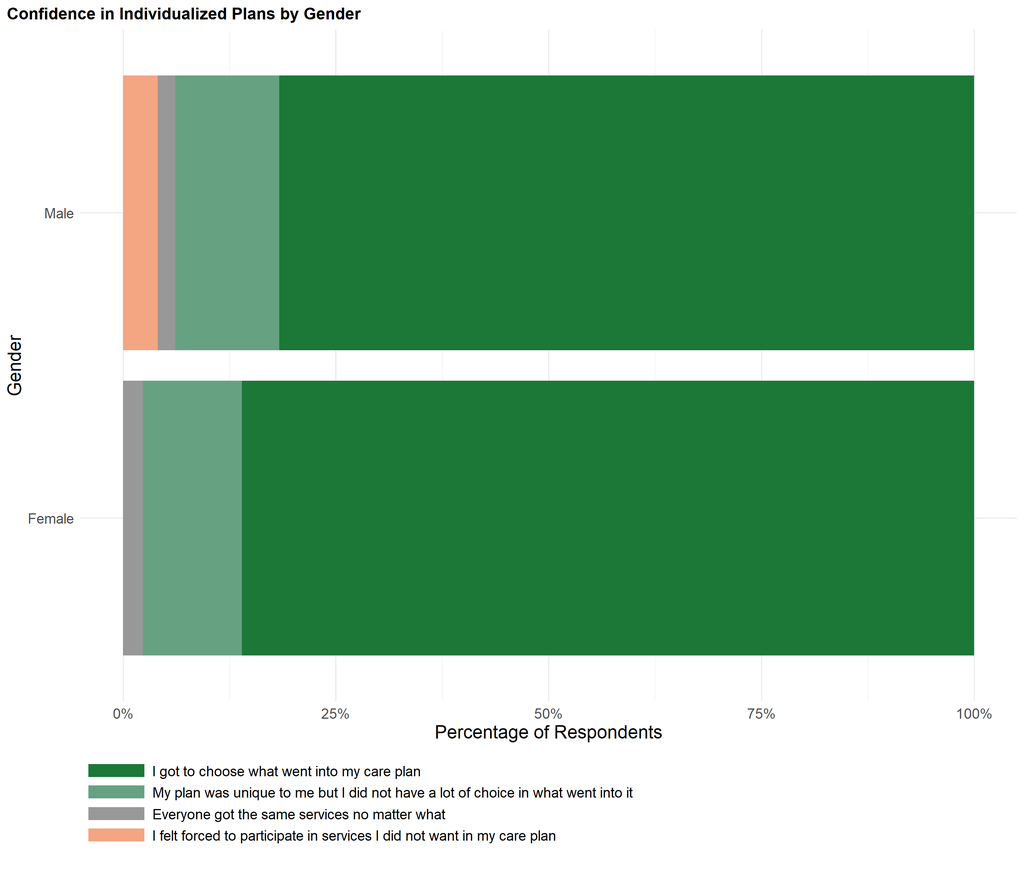

### By Race/Ethnicity

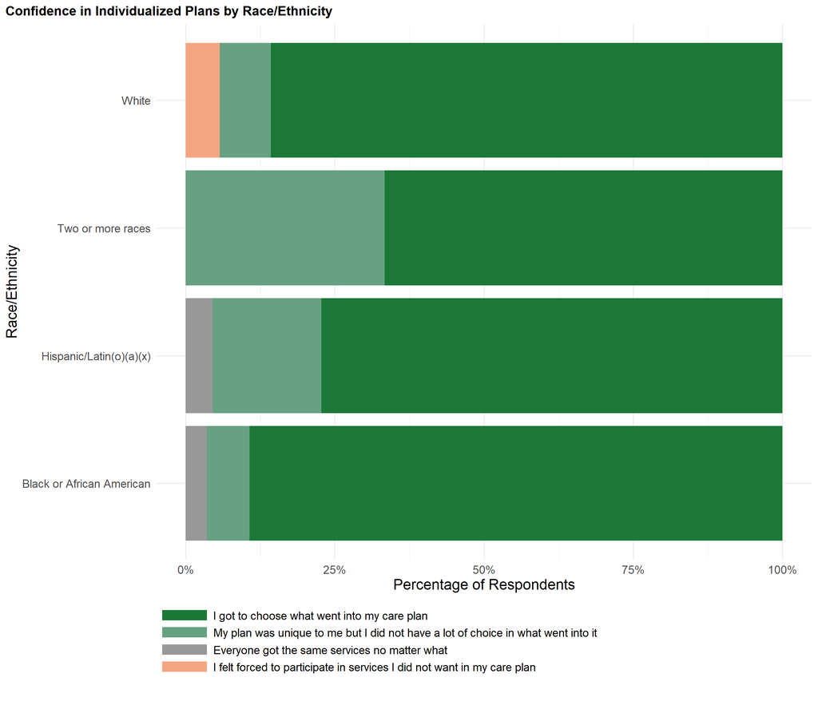

## Program Staff Follow-Through

**“Do the program staff do what they say they are going to do in a timely manner?”**

### By Age Group

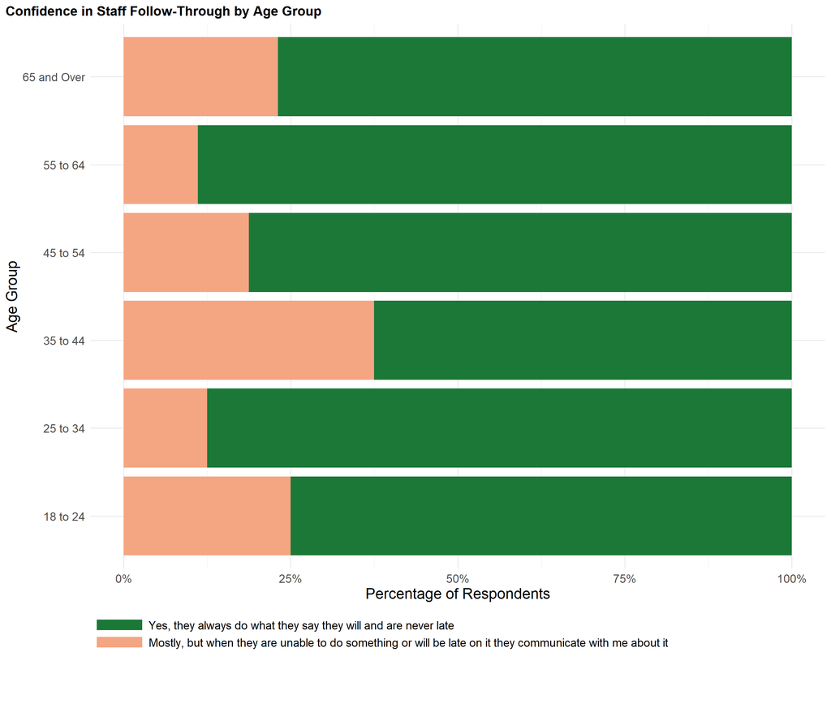

### By Chronic Status

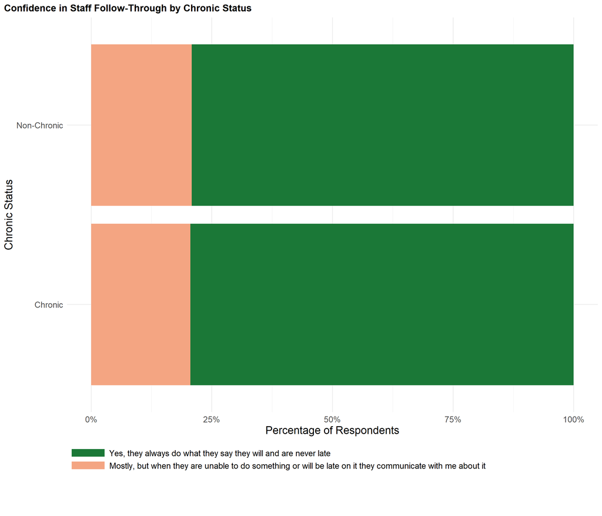

### By Gender

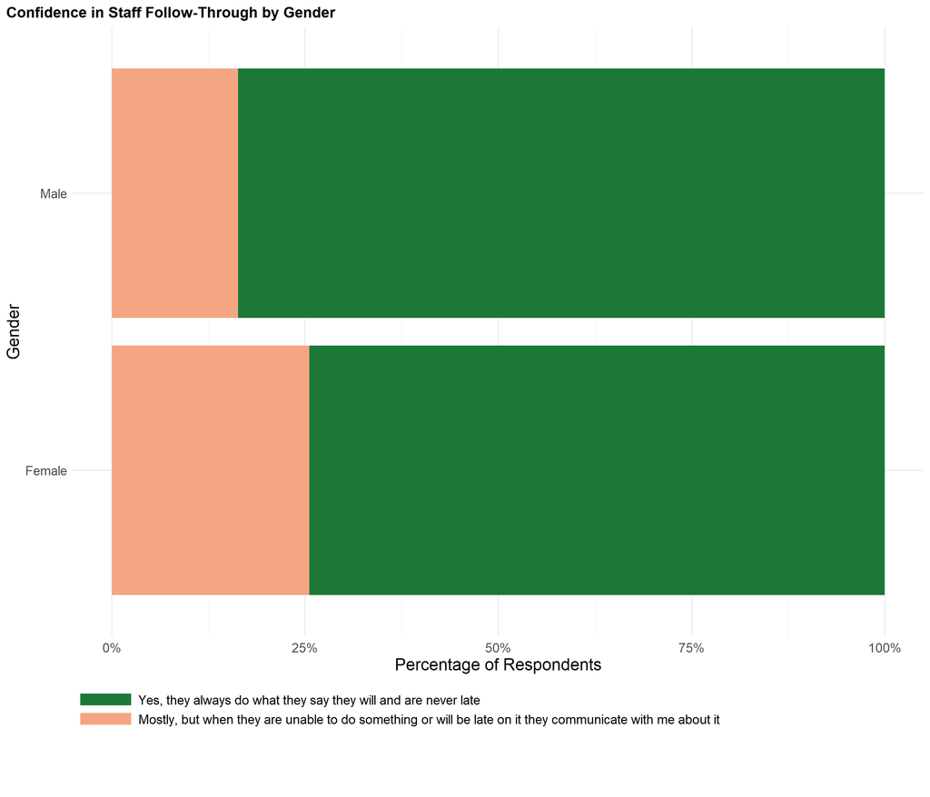

### By Race/Ethnicity

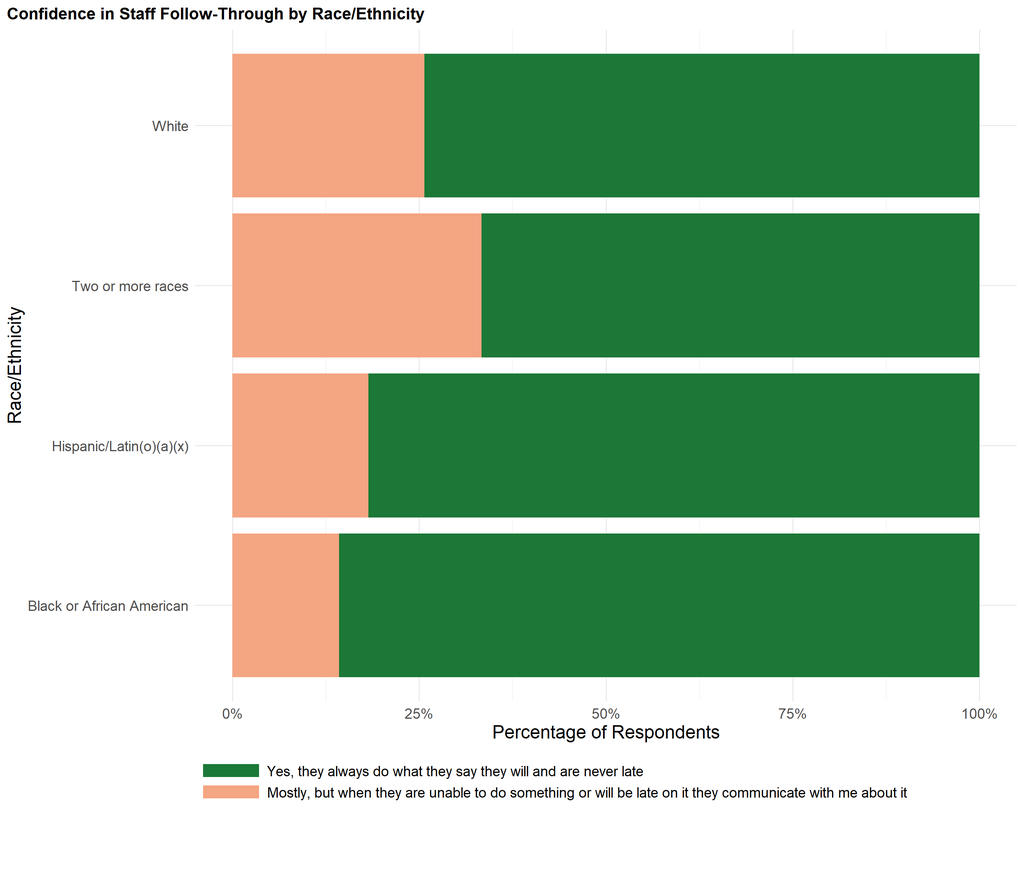